# Assignment 6

USER

February 25, 2018

# Analytical Results

Since
$$\bar{X}=\frac{1}{n}\sum_{i=1}^{n}X_i \sim N(\mu,\frac{1}{n})$$
the power function is
$$\beta(\alpha,\mu)=Pr\{|\frac{\bar{X}-0}{\sqrt{\frac{1}{n}}}|>C_{\alpha/2}|\mu\}=1-Pr\{|\frac{\bar{X}}{\sqrt{\frac{1}{n}}}|\leq C_{\alpha/2}|\mu\}=1-Pr\{-C_{\alpha/2} \sqrt{\frac{1}{n}} \leq \bar{X} \leq C_{\alpha/2} \sqrt{\frac{1}{n}}|\mu\}$$
That is
$$\beta(\alpha,\mu)=1-Pr\{-C_{\alpha/2}-\sqrt{n}\mu \leq \frac{\bar{X}-\mu}{\sqrt{\frac{1}{n}}} \leq C_{\alpha/2}-\sqrt{n}\mu | \mu\}=\phi(\sqrt{n}\mu-C_{\alpha/2}) + \phi(-\sqrt{n}\mu-C_{\alpha/2})$$
which is strictly increasing w.r.t. $|\sqrt{n}\mu|$.

# Simulation Results 1

From the graph below, we see that power increases with n and $|\mu|$. When mu is 0, power is invariant with respect to n and is equal to $\alpha$. This is compatible with our theoretical result.

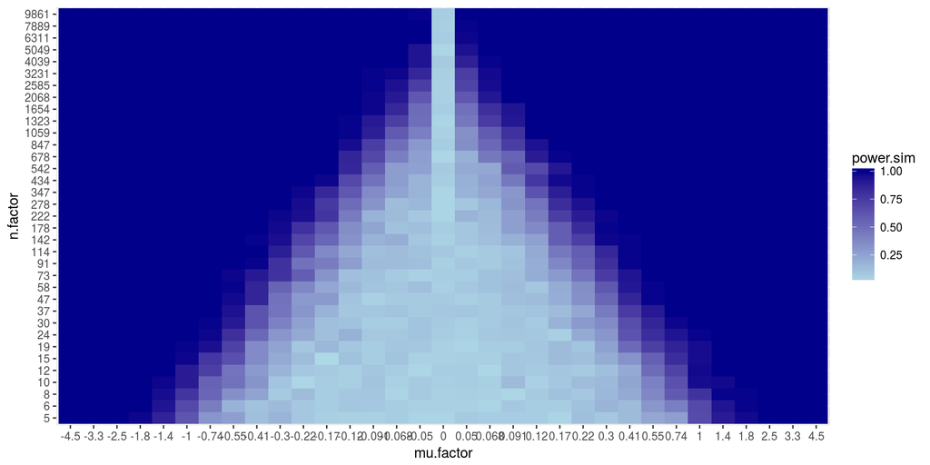

# Simulation Results 2

For the left plot, for a fixed n, power increases with size of mu. The rate of power convergence to 1 is faster with larger n. For the right plot, for a fixed mu, power increases with n. The rate of power convergence to 1 is faster for larger mu.

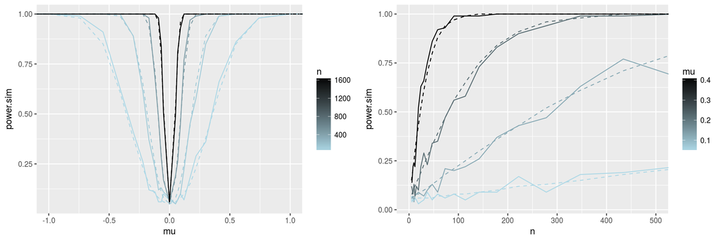

# Finding n

Based on the previously derived power function, we use the uniroot function to find the n given a specific power.

```r
power=function(x){
  c=qnorm(0.05/2,mean=0,sd=1, lower.tail=F) # alpha=0.05
  pnorm(x-c,mean=0,sd=1,lower.tail = T) + pnorm (-x-c,mean=0,sd=1,lower.tail = T)
}
inverse=function(p) uniroot(function(x) power(x)-p, lower=0, upper=10^6)$root
find.n=function(mu,p) ceiling((inverse(p)/mu)^2)
```

```r
find.n(1,0.8)
```

```
## [1] 8
```

```r
find.n(1,0.9)
```

```
## [1] 11
```

# Local power: theretical discussion

Since
$$\beta(\alpha,\mu)=\phi(\sqrt{n}\mu-C_{\alpha/2}) + \phi(-\sqrt{n}\mu-C_{\alpha/2})$$
we have:
1. good student
$$\mu=2/\sqrt{n} \implies \beta(\alpha,\mu)=\phi(2-C_{\alpha/2}) + \phi(-2-C_{\alpha/2})$$
which is a constant and a little bit above $0.5$ if $\alpha=0.05$.
2. turtle
$$\mu=2/n^{0.4} \implies \beta(\alpha,\mu)=\phi(2n^{0.1}-C_{\alpha/2}) + \phi(-2n^{0.1}-C_{\alpha/2})$$
which is strictly increasing w.r.t. $n$ and converges to $1$.
3. rabbit
$$\mu=2/n^{0.6} \implies \beta(\alpha,\mu)=\phi(2/n^{0.1}-C_{\alpha/2}) + \phi(-2/n^{0.1}-C_{\alpha/2})$$
which is strictly decreasing w.r.t. $n$ and converges to $\alpha$, say $0.05$.
Back to our post test estimator $\tilde{\beta}$, it is still consistent but its asymptotic distribution doesn’t converge to the distribution of the unrestricted OLS estimator. In fact, it is a mix when $n$ goes to infinity given that the power of the post test converges to $\alpha \in (0,1)$.

# Local power: graph respresentation

The graph below is expected based on the previous theoretical derivations.

[figure not shown]